# < 중고나라 거래 트렌드 분석 - 운동용품 (허채범) >

### * 수요가 있어야 매매가 발생하는 것

### * 중고나라에서 관심이나 인기의 척도는 될 수 있음

### * 트렌드를 반영한다는 전제하에 분석 시작

### * 이를 바탕으로 관련 업체는 어떤 전략을 활용해야 하는지 생각해보자

# < 목차 >

### 0. 모듈, 함수 관련

-> 게시판 전체 크롤링 / 기간 & 검색어 입력 후, 크롤링 / 그외 게시판 그래프 그리기

### 1. 요가/운동용품 게시판 ( 6개월간 (22.01.31 - 22.07.27) ) --- 여성

1) 워드클라우드  
2) 줌바/폴댄스/요가 관심도 비교  
3) 상위 20개 비교

### 2. 헬스/수영/용품/의류 게시판 (1달치, 2년치) --- 남성

1) 1달치(22.06.18 - 22.07.26) 데이터  
2) 2년치(20.07.23 - 22.07.26) 데이터  
3) 1달치와 2년치 상위 단어 20개 비교

### 모듈 관련

```python
# 모듈 관련
import time
import datetime as dt
from dateutil.relativedelta import relativedelta

from selenium import webdriver
from selenium.webdriver.common.by import By

from bs4 import BeautifulSoup
from wordcloud import WordCloud
from konlpy.tag import Okt
import matplotlib.pyplot as plt

import csv
import platform
import pandas as pd
from collections import Counter

# 한글 폰트
if(platform.system() == 'Windows'):
    plt.rc('font', family='Malgun Gothic')
else:
    plt.rc('font', family='AppleGothic')
```

### i) 게시판 전체 크롤링

```python
# 중고나라 네이버 카페 접속 함수----------------------------------------------------------------------

def openUrl(driver):
    # 로그인 정보
    login_url = 'https://nid.naver.com/nidlogin.login'
    naver_id = "qweriii1977"
    naver_pw = "fkfk2rj2@!##H"

    # 드라이버 실행 후 로그인
    driver.get(login_url)
    driver.implicitly_wait(2)

    # execute_script 함수 사용하여 자바스크립트로 id,pw 넘겨주기
    driver.execute_script("document.getElementsByName('id')[0].value=\'" + naver_id + "\'")
    driver.execute_script("document.getElementsByName('pw')[0].value=\'" + naver_pw + "\'")

    # 로그인 버튼 클릭하기
    driver.find_element(By.XPATH, '//*[@id="log.login"]').click()
    time.sleep(1)

    # 기기등록 버튼 클릭하기
    driver.find_element(By.XPATH, '//*[@id="new.save"]').click()
    time.sleep(1)

# 크롤링 하기-------------------------------------------------------------------------------------

def crawling(page_url, text):
    # 크롤링 진행하려는 카페 주소(중고나라)
    for i in range(1,1001):
        cafe_url = page_url.format(i)
        driver.get(cafe_url)
        time.sleep(1)

        # iframe으로 접근
        driver.switch_to.frame('cafe_main')
        soup = BeautifulSoup(driver.page_source, 'html.parser')
        # soup = soup.find_all(class_='article-board m-tcol-c')[0]

        # 네이버 카페 구조 확인후 게시글 내용만 가저오기
        datas = soup.find_all(class_='td_article')
        dates = soup.find_all(class_='td_date')

        for data in datas:
            article_title = data.find(class_='article')
            link = article_title.get('href')
            article_title = article_title.get_text().strip()

            # 어떤 컨셉으로 뽑아낼지에 대한
            text.append(article_title)
    # print(test)

# WordCloud 그리기 함수1----------------------------------------------------------------------

def draw_wc(text):

    print(len(text))
    okt = Okt()
    tags = []

    for txt in text:
        sentences_tag = okt.pos(txt)
        # tag가 명사인 단어들만 noun_adj_list에 넣어준다.
        for word, tag in sentences_tag:
            if tag in ['Noun']:
                tags.append(word)

    # 가장 많이 나온 단어부터 100개를 저장한다.
    counts = Counter(tags)
    # print(counts)
    tags = counts.most_common(100)
    # print(tags)

    # 한글폰트 사용
    if platform.system() == 'Windows':
        path = r'c:\Windows\Fonts\malgun.ttf'
    elif platform.system() == 'Darwin': # Mac OS
        path = r'/System/Library/Fonts/AppleGothic'
    else:
        path = r'/usr/share/fonts/truetype/name/NanumMyeongjo.ttf'

    wc = WordCloud(font_path=path, background_color="white", max_font_size=60)
    cloud = wc.generate_from_frequencies(dict(tags))

    # 생성된 WordCloud를 test.jpg로 보낸다.
    #cloud.to_file('test.jpg')
    plt.figure(figsize=(10, 8))
    plt.axis('off')
    plt.imshow(cloud)
    plt.show()
```

### ii) 기간 & 검색어 입력 후, 크롤링

```python
# 기간 & 검색어 입력 후, 자료 크롤링하는 함수들 ----------------------------------------------------------------------
# 리스트 만들기
def createList(driver, item_title, item_date):
    now = dt.datetime.now()
    date = now

    while True:
        count = 1

        while True:
            # 크롤링 진행하려는 카페 주소(중고나라)
            cafe_url = '''
            https://cafe.naver.com/joonggonara?iframe_url=/ArticleSearchList.nhn%3Fsearch.clubid=10050146%26search.
            menuid=440%26search.media=0%26search.searchdate={0}{1}%26search.defaultValue=1%26userDisplay=15%26search.
            onSale=1%26search.option=3%26search.sortBy=date%26search.searchBy=0%26search.searchBlockYn=0%26search.
            query=kg%26search.viewtype=title%26search.page={2}
            '''.format(dt.datetime.strftime(date - dt.timedelta(days=6), '%Y-%m-%d'), dt.datetime.strftime(date, '%Y-%m-%d'), count)

            driver.get(cafe_url)

            # iframe으로 접근
            driver.switch_to.frame('cafe_main')
            soup = BeautifulSoup(driver.page_source, 'html.parser')

            # 네이버 카페 구조 확인후 게시글 내용만 가저오기
            datas = soup.find_all(class_='td_article')
            dates = soup.find_all(class_='td_date')

            if datas == []:
                break

            for data in datas:
                article_title = data.find(class_='article')
                article_title = article_title.get_text().strip()
                item_title.append(article_title)

            for day in dates: item_date.append(day.text)

            count += 1

        date = date - dt.timedelta(weeks=1)
        if date < (now - relativedelta(years=2)): break

# 도배글 방지 (중복글 제목 제거)-----------------------------------------------------------------
def createCSV(item_title, item_date):
    data = {'Title': item_title, 'Date': item_date}
    df = pd.DataFrame(data)
    df.drop_duplicates(['Title'], ignore_index=True, inplace=True)
    df.to_csv('item_list.csv', encoding='utf-8-sig')

# WordCloud 그리기 함수1----------------------------------------------------------------------
def draw_wordcloud():
    item_title = []
    item_date = []

    driver = webdriver.Chrome('C:\workspace\chromedriver')

    openUrl(driver)
    createList(driver, item_title, item_date)
    createCSV(item_title, item_date)

    ###############
    okt = Okt()
    tags = []
    ###############

    for txt in item_title:
        sentences_tag = okt.pos(txt)
        # tag가 명사인 단어들만 noun_adj_list에 넣어준다.
        for word, tag in sentences_tag:
            if tag in ['Noun']:
                tags.append(word)

    counts = Counter(tags)
#     print(counts)
    tags = counts.most_common(100)
#     print(tags)

    if platform.system() == 'Windows':
        path = r'c:\Windows\Fonts\malgun.ttf'
    elif platform.system() == 'Darwin': # Mac OS
        path = r'/System/Library/Fonts/AppleGothic'
    else:
        path = r'/usr/share/fonts/truetype/name/NanumMyeongjo.ttf'

    wc = WordCloud(font_path=path, background_color="white", max_font_size=60)
    cloud = wc.generate_from_frequencies(dict(tags))
#     print(cloud)

    # 생성된 WordCloud를 test.jpg로 보낸다.
    #cloud.to_file('test.jpg')
    plt.figure(figsize=(10, 8))
    plt.axis('off')
    plt.imshow(cloud)
    plt.show()
```

### iii) 게시판 그래프 그리기

```python
def draw_graph0():
    popD = pd.read_csv('줌바vs폴댄스vs요가.csv', encoding='utf-8', header=1)
    popD.rename(columns={'일':'일자','줌바: (대한민국)':'줌바', '폴댄스: (대한민국)':'폴댄스',
                         '요가: (대한민국)':'요가'}, inplace=True)
    popD = popD.set_index('일자')
    popD.plot(figsize=(13,7))

    plt.title('6개월(22.01.31 - 22.07.27)간 관심도 비교', fontsize='25')
    plt.ylabel('종목', fontsize='22')
    plt.xlabel('연도', fontsize='22')
    plt.rcParams['lines.linewidth'] = 4
    plt.yticks(fontsize = 15)
    plt.xticks(fontsize = 15)
    plt.legend(fontsize=20)
    plt.show()

def element_graph1():

    # 상위 20개 그래프 그리기
    # (전역함수 선언x, 그냥 꺼내쓰기)
    tags1 = [('나이키', 1887), ('판매', 1886), ('양말', 1879), ('웨어', 1744), ('정품', 1496), ('재고', 1387), ('처리', 1383), ('스포츠', 1156), ('레몬', 1075), ('상품', 1072),
             ('룰루', 1072), ('폴', 1051), ('사이즈', 1043), ('줌바', 1035), ('필라테스', 991), ('아디다스', 980), ('요가', 920), ('레깅스', 911), ('쿠션', 755), ('무드라', 732)]

    words_list = []
    num_list = []
    for words, num in tags1:
        words_list.append(words)
        num_list.append(num)

    x = words_list
    y = num_list

def draw_graph1():


    plt.figure(dpi=150)
    # plt.bar(x,y, color='dodgerblue')

    colors = ['red','blue','blue','red','blue','blue','blue','blue','red','blue',
              'red','blue','blue','blue','blue','red','red','red','blue','red']

    plt.bar(x,y, color = colors)
    plt.xticks(x, rotation=80, fontsize = 11)

    plt.ylim(500, 2000)
    plt.title("[요가/운동용품] 상위20개", size=12)
    for i in range(len(x)):
        height = y[i]
        plt.text(x[i], height + 0.25, '%.f' %height, ha='center', va='bottom', size = 5)
    plt.style.use('ggplot')
    plt.show()
```

```python
def element_graph2():
    # 그래프 요소 1
    b_all = [('판매', 2703), ('수영복', 1399), ('나이키', 1020), ('사이즈', 999), ('상품', 952), ('양말', 654), ('벤치', 652), ('헬스', 636), ('가드', 616), ('랙', 584), ('제품', 583), ('프로', 564), ('봉', 560), ('용', 545), ('래쉬', 513), ('원판', 488), ('스', 475), ('아디다스', 475), ('홈짐', 457), ('정품', 452), ('배럴', 431)]

    x1 = []
    y1 = []
    for words, num in b_all:
        x1.append(words)
        y1.append(num)

    # print(x1)
    # print(y1)

    # 그래프 요소 2
    a_kg = [('판매', 352), ('원판', 242), ('아령', 241), ('덤벨', 215), ('중량', 139), ('운동', 114), ('봉', 91), ('고무', 87), ('중고', 83), ('일괄', 83), ('코팅', 77), ('케틀벨', 76), ('신품', 74), ('기구', 71), ('등', 64), ('벤치', 63), ('바벨', 60), ('로잉머신', 57), ('홈트', 56), ('각종', 56), ('도구', 56)]

    x2 = []
    y2 = []
    for words, num in a_kg:
        x2.append(words)
        y2.append(num)

    # print(x2)
    # print(y2)

def draw_graph2():
    fig, axes = plt.subplots(2,1, figsize=(15,10))

    plt.subplot(2,1,1)

    colors1 = ['silver','orange','silver','silver','silver','silver','red','red','silver','red',
              'silver','silver','red','silver','silver','red','silver','silver','red','silver','orange']

    plt.bar(x1,y1, color = colors1)
    plt.xticks(x1, rotation=80, fontsize = 14)

    plt.title('단어 빈도 상위 20개', fontsize='22')
    plt.ylabel('빈도수', fontsize='20')
    plt.ylim(400,3000)
    for i in range(len(x1)):
        height = y1[i]
        plt.text(x1[i], height + 0.25, '%.f' %height, ha='center', va='bottom', size = 12)
    plt.style.use('ggplot')

    plt.subplots_adjust(left=0.125, bottom=0.1, right=0.9, top=0.9, wspace=0.2, hspace=0.3)

    plt.subplot(2,1,2)

    colors2 = ['silver','red','red','red','red','silver','red','silver','silver','silver',
              'silver','red','silver','silver','silver','red','red','red','red','silver','silver']

    plt.bar(x2,y2, color = colors2)
    plt.xticks(x2, rotation=80, fontsize = 14)

    # plt.title('업종별 종사자수(명)')
    plt.ylabel('빈도수', fontsize='20')
    plt.xlabel('단어', fontsize='20')
    for i in range(len(x2)):
        height = y2[i]
        plt.text(x2[i], height + 0.25, '%.f' %height, ha='center', va='bottom', size = 12)
    plt.style.use('ggplot')
    plt.show()
```

## 1. [요가/운동용품] 게시판 --- 여성

### 1) 6개월간 (22.01.31 - 22.07.27) => 워드클라우드

```
15012
```

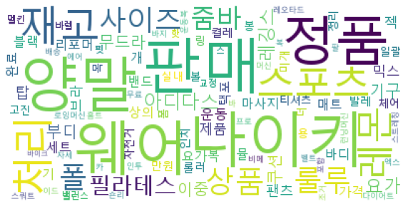

```python
# 드라이버 경로 불러오기
driver = webdriver.Chrome('C:\workspace\chromedriver')

# 중고나라 네이버 카페 접속하기
openUrl(driver)

# 크롤링 하기
test = []
page_url = '''https://cafe.naver.com/joonggonara?iframe_url=/ArticleList.nhn%3Fsearch.clubid=10050146%26search.
            menuid=374%26search.boardtype=L%26search.totalCount=151%26search.cafeId=10050146%26search.page={}'''
crawling(page_url, test)

# WordCloud 그리기
draw_wc(test)
```

- 인기 종목 관련 : 필라테스, 폴, 요가, 줌바
- 인기 브랜드 관련 : 무드라, 룰루, 레몬, 뮬
- 한국기업평판연구소
- 레깅스 브랜드 2022년 6월
- 젝시믹스(2), 아디다스(3), 나이키(4), 룰루레몬(7), 부디무드라

### 2) 6개월간 (22.01.31 - 22.07.27) => 줌바/폴댄스/요가 관심도 비교

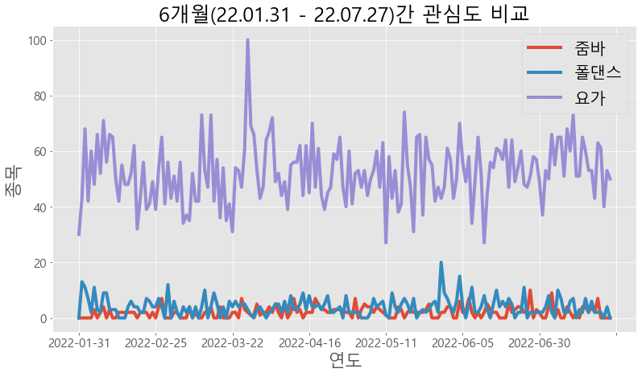

```python
draw_graph0()
```

- 상대적으로 요가의 관심도가 높았음 (독보적)
- 요가 관련 매매가 활발하게 이루어짐
- 개인적으로 줌바나 폴댄스에 대한 인기가 의외

### 3) 6개월간 (22.01.31 - 22.07.27) => 상위 20개 비교

```python
element_graph1()
```

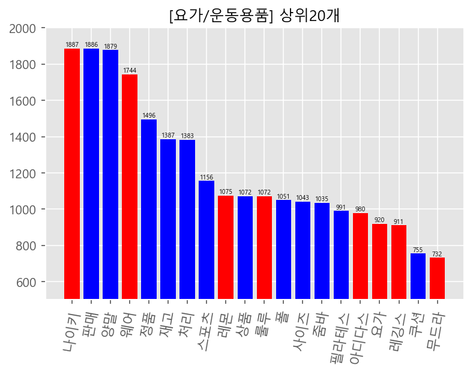

```python
draw_graph1()
```

- 상위 20개 단어들에 랭크된 요가 관련 단어들이 많았다
- 붉게 표시된 바들 관련 단어 (8/20) ### * 레깅스 브랜드 선호도 순위를 참고하면 어느정도 트렌드를 반영한다고 볼 수 있다

## 2. [헬스/수영/용품/의류] 게시판 --- 남성

### 1) 1달치(22.06.18 - 22.07.26) 데이터 --- 1000p

```
15012
```

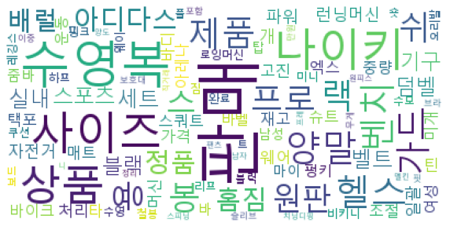

```python
# 드라이버 경로 불러오기
driver = webdriver.Chrome('C:\workspace\chromedriver')

# 중고나라 네이버 카페 접속하기
openUrl(driver)

# 크롤링 하기
test1 = []
page_url1 = '''https://cafe.naver.com/joonggonara?iframe_url=/ArticleList.nhn%3Fsearch.clubid=10050146%26search.
            menuid=440%26search.boardtype=L%26search.totalCount=151%26search.cafeId=10050146%26search.page={}'''
crawling(page_url1, test1)

# WordCloud 그리기
draw_wc(test1)
```

- 봉, 홈짐, 원판, 헬스, 랙 => 홈트 위주 (기본적)
- 배럴, 수영복 => 계절적 특수성

### 2) 2년치(20.07.23 - 22.07.26) 데이터

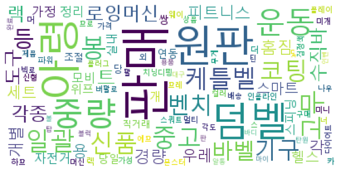

```python
draw_wordcloud()
```

- 2년치지만, 1달치와 비슷한 => 홈트 위주 (기본적)
- but, 위에서 본 '수영복'과 '배럴'은 찾아볼 수 없음
- 상대적으로 브랜드명은 낮은 순위 (이고진, 반석스포츠)
- 핑크 덤벨(존재)

### 3) 1달치와 2년치(20.07.23 - 22.07.26) 상위 단어 20개 비교

```python
# 그래프 요소
element_graph2()
```

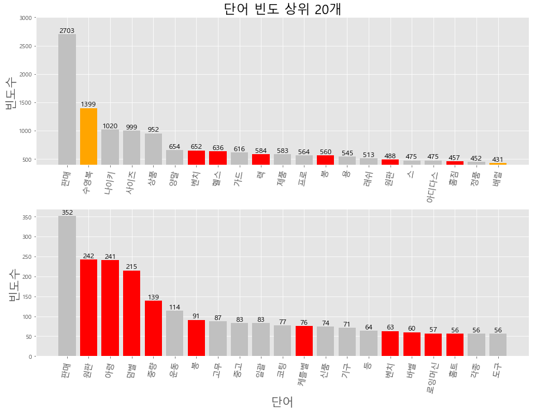

```python
# 그래프 그리기
draw_graph2()
```

- 1달치나 2년치 단어 맥락이 비슷 (홈트, 헬스 관련 단어 포진)
- 크게 유행을 타지 않고, 해당 시장에 고정적인 고객들 있음
- 즉, 남성은 기본적인 품목(홈트 관련) + 계절적 특수성(수영복 등)

## 3. 결론 (트렌드 분석)

### -> 관련 전략은 최종 결론에서

1. 여자 - 요가 관련 상품들의 주 이용자는 여성
- 애슬레저룩에 대한 관심 상승
- 관심 종목과 브랜드의 가지수가 다양
- 요가를 선두로 브랜드별 운동복 매매
1. 남자 - 홈트 관련 상품들의 주 이용자는 남성
- 충성도 높은 고객들이 많음
- 해당 물품들에 대한 고정적인 고객들이 많음
- 진입 장벽이 생각보다 높을 것으로 예상